# Course Project: Prediction Assignment Writeup

Alejandro Betanzos

January 31, 2016

# Background

Using devices such as **Jawbone Up, Nike FuelBand, and Fitbit** it is now possible to collect a large amount of data about personal activity relatively inexpensively. These type of devices are part of the quantified self movement – a group of enthusiasts who take measurements about themselves regularly to improve their health, to find patterns in their behavior, or because they are tech geeks. One thing that people regularly do is quantify how much of a particular activity they do, but they rarely quantify how well they do it. In this project, your goal will be to use data from accelerometers on the belt, forearm, arm, and dumbell of 6 participants. They were asked to perform barbell lifts correctly and incorrectly in 5 different ways. More information is available from the website here.

# Data

The training data for this project are available here: https://d396qusza40orc.cloudfront.net/predmachlearn/pml-training.csv

The test data are available here: https://d396qusza40orc.cloudfront.net/predmachlearn/pml-testing.csv

The data for this project come from this source: http://groupware.les.inf.puc-rio.br/har.

# Loading libraries, data and creation of sets

The first step: load the libraries and data. We make use of the alternative of reading the csv direct from the link, this way, the reproducibility is easiest.

```r
library(caret)
library(randomForest)
```

```r
library(ggplot2)
library(rpart)
train<-read.csv("https://d396qusza40orc.cloudfront.net/predmachlearn/pml-training.csv",na.strings=c("NA","#DIV/0!", ""))
test<-read.csv("https://d396qusza40orc.cloudfront.net/predmachlearn/pml-testing.csv",na.strings=c("NA","#DIV/0!", ""))
```

For reproducibility we set a seed. The first look is the dim of the data set, the names of variables and classes and the characteristics of the variable classe that we will predict

```r
set.seed(8888)
dim(train)
```

```
## [1] 19622   160
```

```r
dim(test)
```

```
## [1]  20 160
```

```r
sapply(train,class)
```

```
##                        X                user_name     raw_timestamp_part_1
##                "integer"                 "factor"                "integer"
##     raw_timestamp_part_2           cvtd_timestamp               new_window
##                "integer"                 "factor"                 "factor"
##               num_window                roll_belt               pitch_belt
##                "integer"                "numeric"                "numeric"
##                 yaw_belt         total_accel_belt       kurtosis_roll_belt
##                "numeric"                "integer"                "numeric"
##      kurtosis_picth_belt        kurtosis_yaw_belt       skewness_roll_belt
##                "numeric"                "logical"                "numeric"
##     skewness_roll_belt.1        skewness_yaw_belt            max_roll_belt
##                "numeric"                "logical"                "numeric"
##           max_picth_belt             max_yaw_belt            min_roll_belt
##                "integer"                "numeric"                "numeric"
##           min_pitch_belt             min_yaw_belt      amplitude_roll_belt
##                "integer"                "numeric"                "numeric"
##     amplitude_pitch_belt       amplitude_yaw_belt     var_total_accel_belt
##                "integer"                "numeric"                "numeric"
##            avg_roll_belt         stddev_roll_belt            var_roll_belt
##                "numeric"                "numeric"                "numeric"
##           avg_pitch_belt        stddev_pitch_belt           var_pitch_belt
##                "numeric"                "numeric"                "numeric"
##             avg_yaw_belt          stddev_yaw_belt             var_yaw_belt
##                "numeric"                "numeric"                "numeric"
##             gyros_belt_x             gyros_belt_y             gyros_belt_z
##                "numeric"                "numeric"                "numeric"
##             accel_belt_x             accel_belt_y             accel_belt_z
##                "integer"                "integer"                "integer"
##            magnet_belt_x            magnet_belt_y            magnet_belt_z
##                "integer"                "integer"                "integer"
##                 roll_arm                pitch_arm                  yaw_arm
##                "numeric"                "numeric"                "numeric"
##          total_accel_arm            var_accel_arm             avg_roll_arm
##                "integer"                "numeric"                "numeric"
##          stddev_roll_arm             var_roll_arm            avg_pitch_arm
##                "numeric"                "numeric"                "numeric"
##         stddev_pitch_arm            var_pitch_arm              avg_yaw_arm
##                "numeric"                "numeric"                "numeric"
##           stddev_yaw_arm              var_yaw_arm              gyros_arm_x
##                "numeric"                "numeric"                "numeric"
```

[output cut: 53 more lines]

```
##                "numeric"                "integer"                "numeric"
##         avg_roll_forearm      stddev_roll_forearm         var_roll_forearm
##                "numeric"                "numeric"                "numeric"
##        avg_pitch_forearm     stddev_pitch_forearm        var_pitch_forearm
##                "numeric"                "numeric"                "numeric"
##          avg_yaw_forearm       stddev_yaw_forearm          var_yaw_forearm
##                "numeric"                "numeric"                "numeric"
##          gyros_forearm_x          gyros_forearm_y          gyros_forearm_z
##                "numeric"                "numeric"                "numeric"
##          accel_forearm_x          accel_forearm_y          accel_forearm_z
##                "integer"                "integer"                "integer"
##         magnet_forearm_x         magnet_forearm_y         magnet_forearm_z
##                "integer"                "numeric"                "numeric"
##                   classe
##                 "factor"
```

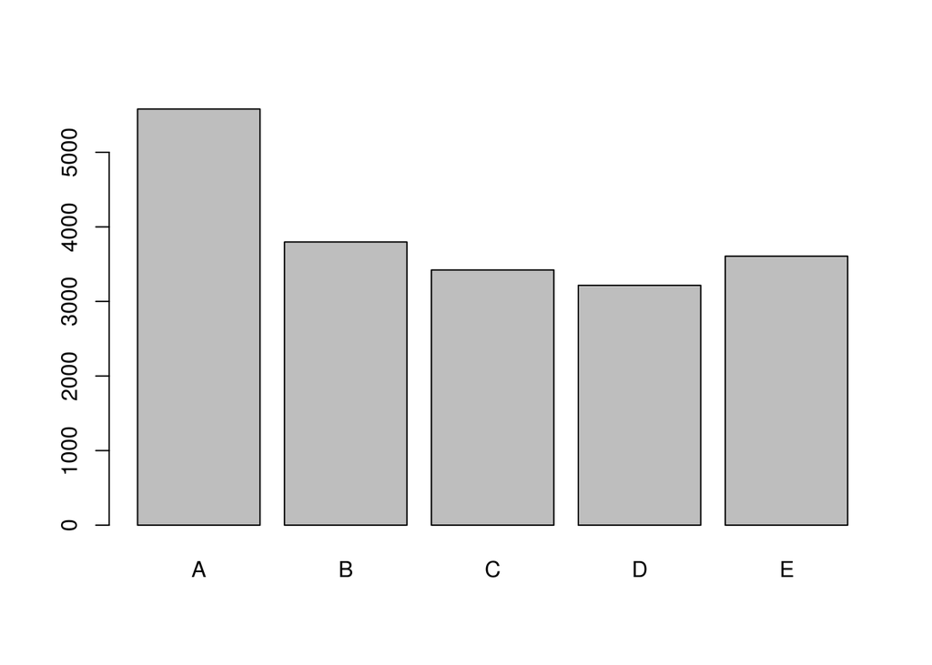

```r
plot(train$classe)
```

We delete all columns with missing values

```r
train<-train[,colSums(is.na(train)) == 0]
test <-test[,colSums(is.na(test)) == 0]
```

Looking at the variables, we can ommit the irrelevant variables as timestamp or user_name (irrelevant for our current purpouses)

```r
train<-train[,-c(1:7)]
test <-test[,-c(1:7)]
```

## The partition

The training data set is partionned into 2 sets: subTrain (75%) and subTest (25%).This will be performed using random subsampling without replacement.

```r
indicators<-createDataPartition(y=train$classe, p=0.75, list=FALSE)
subTrain<-train[indicators, ]
subTest<-train[-indicators, ]
dim(subTrain)
```

```
## [1] 14718    53
```

```r
dim(subTest)
```

```
## [1] 4904   53
```

```r
head(subTrain)
```

```
##   roll_belt pitch_belt yaw_belt total_accel_belt gyros_belt_x gyros_belt_y
## 1      1.41       8.07    -94.4                3         0.00         0.00
## 3      1.42       8.07    -94.4                3         0.00         0.00
## 5      1.48       8.07    -94.4                3         0.02         0.02
## 6      1.45       8.06    -94.4                3         0.02         0.00
## 7      1.42       8.09    -94.4                3         0.02         0.00
## 8      1.42       8.13    -94.4                3         0.02         0.00
##   gyros_belt_z accel_belt_x accel_belt_y accel_belt_z magnet_belt_x
## 1        -0.02          -21            4           22            -3
## 3        -0.02          -20            5           23            -2
## 5        -0.02          -21            2           24            -6
## 6        -0.02          -21            4           21             0
## 7        -0.02          -22            3           21            -4
## 8        -0.02          -22            4           21            -2
##   magnet_belt_y magnet_belt_z roll_arm pitch_arm yaw_arm total_accel_arm
```

[output cut: 69 more lines]

```r
head(subTest)
```

```
##    roll_belt pitch_belt yaw_belt total_accel_belt gyros_belt_x
## 2       1.41       8.07    -94.4                3         0.02
## 4       1.48       8.05    -94.4                3         0.02
## 10      1.45       8.17    -94.4                3         0.03
## 15      1.45       8.20    -94.4                3         0.00
## 18      1.55       8.08    -94.4                3         0.00
## 19      1.57       8.06    -94.4                3         0.00
##    gyros_belt_y gyros_belt_z accel_belt_x accel_belt_y accel_belt_z
## 2          0.00        -0.02          -22            4           22
## 4          0.00        -0.03          -22            3           21
## 10         0.00         0.00          -21            4           22
## 15         0.00         0.00          -21            2           22
## 18         0.02         0.00          -21            5           21
## 19         0.00        -0.02          -20            5           21
##    magnet_belt_x magnet_belt_y magnet_belt_z roll_arm pitch_arm yaw_arm
```

[output cut: 69 more lines]

# Prediction Model: Decision Tree

I will perform a rpart model with the data.

```r
modeltree <- rpart(classe ~ ., data=subTrain, method="class")
predictiontree <- predict(modeltree, subTest, type = "class")
confusionMatrix(predictiontree, subTest$classe)
```

```
## Confusion Matrix and Statistics
##
##           Reference
## Prediction    A    B    C    D    E
##          A 1255  207   14   89   19
##          B   37  489   75   30   60
##          C   35   85  673   75   64
##          D   55   67   61  534   57
##          E   13  101   32   76  701
##
## Overall Statistics
##
##                Accuracy : 0.7447
##                  95% CI : (0.7322, 0.7569)
##     No Information Rate : 0.2845
##     P-Value [Acc > NIR] : < 2.2e-16
##
##                   Kappa : 0.6757
##  Mcnemar's Test P-Value : < 2.2e-16
##
## Statistics by Class:
##
##                      Class: A Class: B Class: C Class: D Class: E
## Sensitivity            0.8996  0.51528   0.7871   0.6642   0.7780
## Specificity            0.9062  0.94893   0.9360   0.9415   0.9445
## Pos Pred Value         0.7923  0.70767   0.7221   0.6899   0.7595
## Neg Pred Value         0.9578  0.89081   0.9542   0.9346   0.9498
## Prevalence             0.2845  0.19352   0.1743   0.1639   0.1837
## Detection Rate         0.2559  0.09971   0.1372   0.1089   0.1429
## Detection Prevalence   0.3230  0.14091   0.1900   0.1578   0.1882
## Balanced Accuracy      0.9029  0.73210   0.8616   0.8028   0.8613
```

# Prediction Model: Random Forest

The first tree was just for comparing with this “more stable” model: randomforest.

```r
modelrf <- randomForest(classe ~. , data=subTrain, method="class")
predictionrf <- predict(modelrf, subTest, type = "class")
confusionMatrix(predictionrf, subTest$classe)
```

```
## Confusion Matrix and Statistics
##
##           Reference
## Prediction    A    B    C    D    E
##          A 1395    0    0    0    0
##          B    0  949    3    0    0
##          C    0    0  852   11    0
##          D    0    0    0  792    4
##          E    0    0    0    1  897
##
## Overall Statistics
##
##                Accuracy : 0.9961
##                  95% CI : (0.994, 0.9977)
##     No Information Rate : 0.2845
##     P-Value [Acc > NIR] : < 2.2e-16
##
##                   Kappa : 0.9951
##  Mcnemar's Test P-Value : NA
##
## Statistics by Class:
##
##                      Class: A Class: B Class: C Class: D Class: E
## Sensitivity            1.0000   1.0000   0.9965   0.9851   0.9956
## Specificity            1.0000   0.9992   0.9973   0.9990   0.9998
## Pos Pred Value         1.0000   0.9968   0.9873   0.9950   0.9989
## Neg Pred Value         1.0000   1.0000   0.9993   0.9971   0.9990
## Prevalence             0.2845   0.1935   0.1743   0.1639   0.1837
## Detection Rate         0.2845   0.1935   0.1737   0.1615   0.1829
## Detection Prevalence   0.2845   0.1941   0.1760   0.1623   0.1831
## Balanced Accuracy      1.0000   0.9996   0.9969   0.9920   0.9977
```

# Conclussion

With this results we can choose “with eyes closed” the random forest model since it has an accuracy of 0.996, with this results we can expect 1 or none error bad classified

#Submission

```r
submission <- predict(modelrf, test, type="class")
submission
```

```
##  1  2  3  4  5  6  7  8  9 10 11 12 13 14 15 16 17 18 19 20
##  B  A  B  A  A  E  D  B  A  A  B  C  B  A  E  E  A  B  B  B
## Levels: A B C D E
```

We can write this result for our submission as follows:

```r
pml_write_files = function(x){
  n = length(x)
  for(i in 1:n){
    filename = paste0("problem_id_",i,".txt")
    write.table(x[i],file=filename,quote=FALSE,row.names=FALSE,col.names=FALSE)
  }
}

pml_write_files(submission)
```